# TP3 MRR

### K-fold cross validation

```r
rows=sample(nrow(tabmed))
tabmed=tabmed[rows,]

## folds

k=10
fold=cut(seq(1,nrow(tabmed)),breaks=k, labels=FALSE)
##
pred.accuracyk.step=c()
pred.recallk.step=c()
pred.error_ratk.step=c()

for (i in 1:k){
  test_rows=which(fold==i, arr.ind=TRUE)
  tab.testk=tabmed[test_rows,]
  tab.traink=tabmed[-test_rows,]

  # regression logistique
  model.full=glm(medHousePriceBin~., family=binomial, data=tab.traink)
  model.stepk=step(model.full,direction='both'); summary(resstep)

  # prediction

  pred_stepk=predict.glm(model.stepk, newdata= tab.testk, type="response")
  Y.pred.step=as.numeric(pred_stepk>0.5)
  confusion_matrix=table(Y.pred.step, tab.testk$medHousePriceBin)
  pred.accuracyk.step[i]=sum(diag(confusion_matrix))/sum(confusion_matrix)*100 # prediction accuracy
  pred.recallk.step[i]=confusion_matrix[2,2]/sum(confusion_matrix[,2])*100
  pred.error_ratk.step[i]=sum(diag(confusion_matrix[1:2,2:1]))/sum(confusion_matrix)*100
}
```

[output not shown]

[output cut: 195 more lines]

[output not shown]

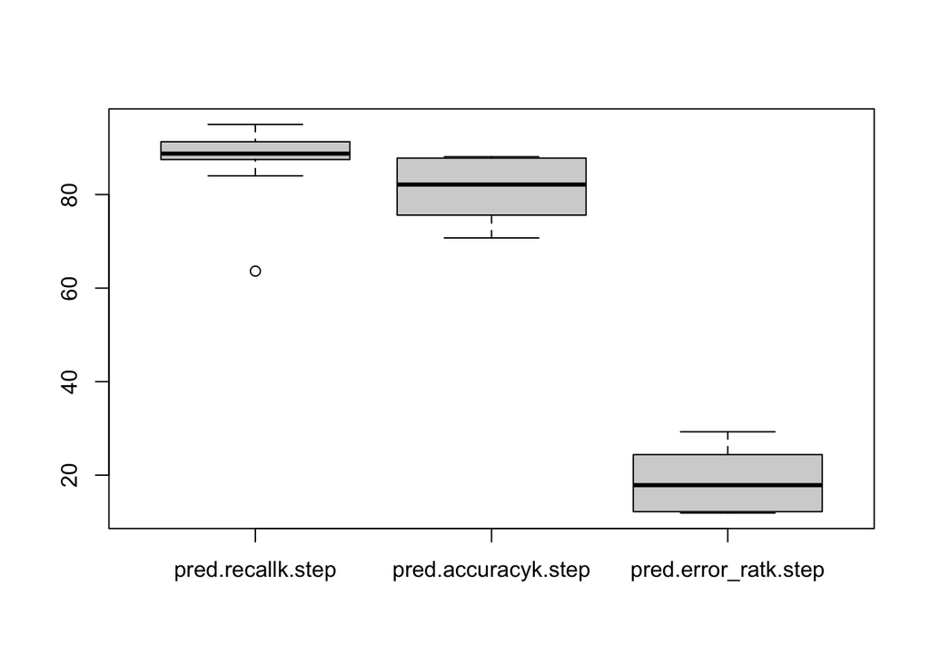

```r
boxplot(data.frame(pred.recallk.step, pred.accuracyk.step, pred.error_ratk.step))
```

En utilisant la validation croisée, on remarque que nous avons une performance globale qui se situe autour de 80%, avec un taux d’erreur autour de 20%.

# Modèle Lasso

On commence par préparer nos données.

```r
X.train = as.matrix(tab.train[,-dim(tab.train)[2]])
X.test = as.matrix(tab.test[,-dim(tab.test)[2]])
Y.test = tab.test$medHousePriceBin
Y.train = tab.train$medHousePriceBin
```

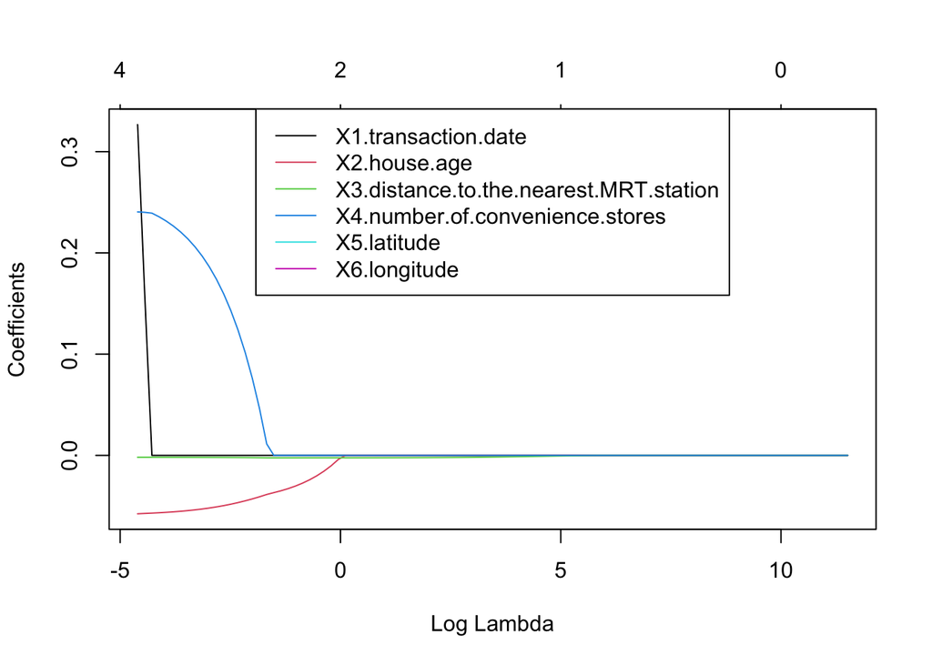

```r
grid = 10^seq(5,-2,length = 100) # sequence des lambda
lasso=glmnet(X.train,Y.train,alpha=1,lambda=grid,family = "binomial", standardize=FALSE)
plot(lasso,xvar="lambda",type="l",col=1:10);legend("top",legend=colnames(X.train[,1:ncol(X.train)]), col=1:10, lty=1)
```

On voit que plus lambda est grand, plus le nombre de variables sélectionnées est petit.

```r
lasso.cv.out=cv.glmnet(X.train, Y.train, alpha = 1,nfolds = 10,family = "binomial"); lasso.cv.out
```

```
##
## Call:  cv.glmnet(x = X.train, y = Y.train, nfolds = 10, alpha = 1, family = "binomial")
##
## Measure: Binomial Deviance
##
##      Lambda Measure      SE Nonzero
## min 0.00485  0.8004 0.07931       5
## 1se 0.03755  0.8708 0.04784       4
```

```r
lasso.min=lasso.cv.out$lambda.min # on sélectionne le plus petit lambda qui minimise le MSE
```

```r
lasso.min.pred= predict(lasso, s=lasso.min, newx=X.test, type="response")
lasso.min.predBin=as.numeric(lasso.min.pred>0.5) # transforme les données en données binaire avec un seuil de 1/2

confusion_matrix.lasso = table(lasso.min.predBin,Y.test) # on crée la matrice de confusion
confusion_matrix.lasso
```

```
##                  Y.test
## lasso.min.predBin  0  1
##                 0 37 12
##                 1  5 42
```

VHINY: attention il faut que tu modifies la valeur (à l’endroit [1,0] de la matrice c’est les faux positifs et l’endroit [0,1] les faux négatifs)

## Courbe ROC et AUC

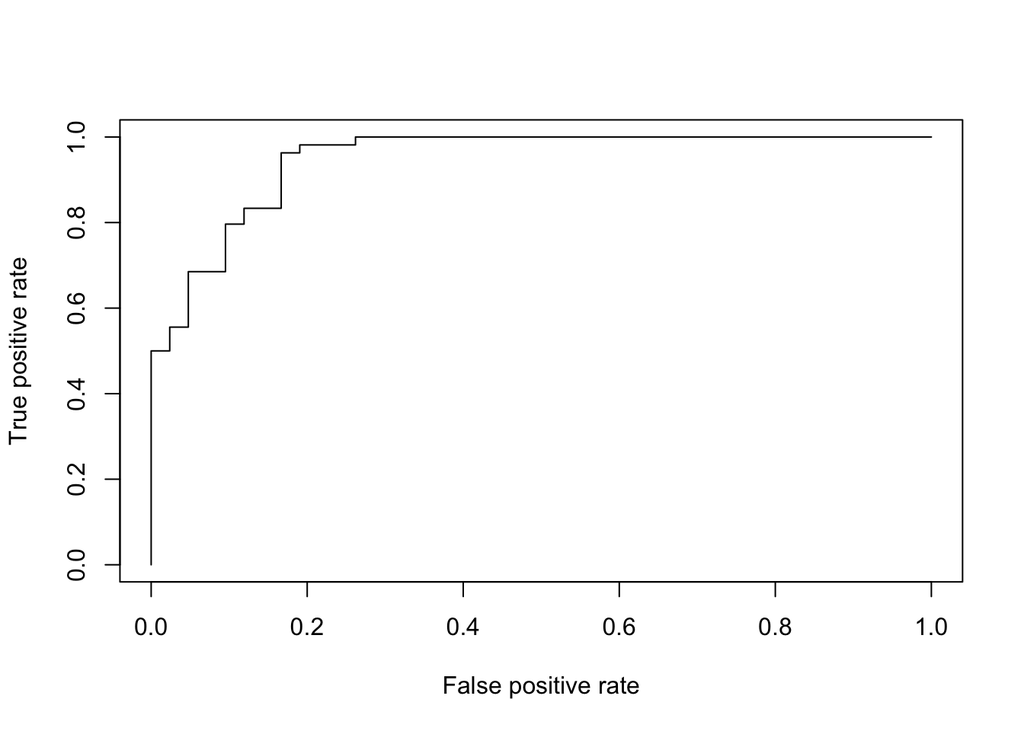

```r
pred.lasso.min=prediction(lasso.min.predBin,tab.test$medHousePriceBin)
perf.lasso.min=performance(pred.lasso.min, "tpr" ,"fpr")
plot(perf)
```

```r
ROC_auc.lasso=performance(pred.lasso.min,"auc")
AUC.lasso=ROC_auc.lasso@y.values[[1]]
print(AUC.lasso)
```

```
## [1] 0.8293651
```

## K-folds cross validation

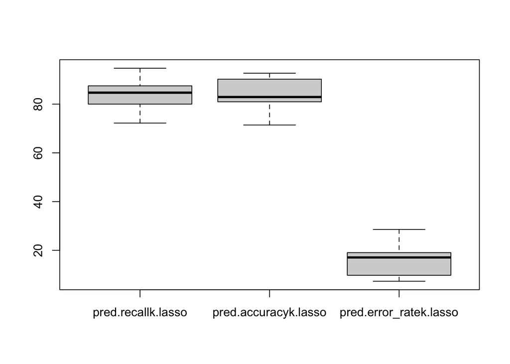

```r
##shuffling
rows <- sample(nrow(tabmed))
tabmed <- tabmed[rows, ]
## folds
k = 10
fold = cut(seq(1,nrow(tabmed)), breaks = k,labels = FALSE)
##
pred.accuracyk.lasso = c()
pred.recallk.lasso = c()
pred.error_ratek.lasso = c()

for (i in 1:k) {
  test_rows = which(fold == i,arr.ind = TRUE)
  tab.testk = tabmed[test_rows,]
  tab.traink = tabmed[-test_rows,]

  X.train = as.matrix(tab.traink[,-dim(tab.traink)[2]])
  X.test = as.matrix(tab.testk[,-dim(tab.testk)[2]])
  Y.test = tab.testk$medHousePriceBin
  Y.train = tab.traink$medHousePriceBin

### regression lasso

  grid = 10^seq(5,-2,length = 100) # sequence des lambda
  lasso.k=glmnet(X.train,Y.train,alpha=1,lambda=grid,family = "binomial", standardize=FALSE)
  lasso.cv.out=cv.glmnet(X.train, Y.train, alpha = 1,nfolds = 10,family = "binomial");
  lasso.mink=lasso.cv.out$lambda.min # on sélectionne le plus petit lambda qui minimise le MSE
  lasso.min.predk= predict(lasso, s=lasso.min, newx=X.test, type="response")
  lasso.min.predBink=as.numeric(lasso.min.predk>0.5)

  # matrice de confusion et performance

  confusion_matrix=table(lasso.min.predBink,Y.test)

  pred.accuracyk.lasso[i]=sum(diag(confusion_matrix))/sum(confusion_matrix)*100
  pred.recallk.lasso[i]=confusion_matrix[2,2]/sum(confusion_matrix[,2])*100
  pred.error_ratek.lasso[i]=sum(diag(confusion_matrix[1:2,2:1]))/sum(confusion_matrix)*100
}

boxplot(data.frame(pred.recallk.lasso,pred.accuracyk.lasso,pred.error_ratek.lasso))
```